Documentação do pacote Package documentation

# Tutorial de Uso do Pacote Bioma Stats Bioma Stats Package User Tutorial

Prof. Dr. Iuri E. P. Ferreira · Atualizado em 01/06/2026 Prof. Dr. Iuri E. P. Ferreira · Updated June 1, 2026

Arte de capa gerada com o Fable 5. Cover art generated with Fable 5.

# Tutorial de Uso do Pacote Bioma Stats

Prof. Dr. Iuri E. P. Ferreira

01/06/2026. Atualizado em 01/06/2026.

# Sobre o Bioma StatsAbout Bioma Stats

O *Bioma Stats* é um pacote em R criado para facilitar o processamento e a análise de dados geoespaciais, com foco em uso e cobertura da terra (Land Use and Land Cover - LULC) no território brasileiro. O pacote foi desenvolvido para automatizar fluxos de trabalho complexos em análises ambientais, desde o download dos dados até a visualização dos resultados, sendo uma ferramenta acessível até para usuários iniciantes no R.The *Bioma Stats* is an R package created to facilitate the processing and analysis of geospatial data, with a focus on land use and land cover (LULC) across Brazilian territory. The package was developed to automate complex workflows in environmental analyses, from data download to results visualization, making it an accessible tool even for beginners in R.

## Funcionalidades PrincipaisMain Features

### Importação de dados geoespaciaisGeospatial data import

Integra dados de fontes como o projeto MapBiomas e o OpenStreetMap, permitindo análises detalhadas de atributos espaciais como proximidade a rodovias e corpos d’água.Integrates data from sources such as the MapBiomas project and OpenStreetMap, enabling detailed analyses of spatial attributes such as proximity to roads and water bodies.

### Métricas de paisagemLandscape metrics

Cálculo de métricas como fragmentação, densidade de borda e evolução temporal do uso do solo, essenciais para estudos de conservação e planejamento ambiental.Calculation of metrics such as fragmentation, edge density, and temporal evolution of land use, essential for conservation studies and environmental planning.

### Visualização de resultadosResults visualization

Visualização de mapas LULC e análises customizadas em áreas de interesse, definidas por shapefiles ou polígonos desenhados pelo usuário.Visualization of LULC maps and customized analyses in areas of interest, defined by shapefiles or user-drawn polygons.

### Exportação pronta para análiseAnalysis-ready export

Exporta mapas recortados, tabelas de áreas, métricas de paisagem e objetos `.Rdata` no padrão Bioma Stats, prontos para uso imediato em R ou compartilhamento entre pesquisadores.Exports clipped maps, area tables, landscape metrics, and `.Rdata` objects in the Bioma Stats standard, ready for immediate use in R or sharing among researchers.

### Aquisição flexível dos dadosFlexible data acquisition

Download da coleção completa via `download_mapbiomas` ou uso de coleções locais, sem servidores intermediários.Download of the full collection via `download_mapbiomas` or use of local collections, without intermediate servers.

Com o *Bioma Stats*, o usuário pode automatizar várias etapas da análise ambiental, tornando o processo mais eficiente e menos suscetível a erros. O pacote é recomendado para pesquisadores de diversas áreas interessados em realizar análises ambientais com dados georreferenciados de maneira prática e intuitiva.With *Bioma Stats*, users can automate several steps of environmental analysis, making the process more efficient and less error-prone. The package is recommended for researchers from diverse fields interested in conducting environmental analyses with georeferenced data in a practical and intuitive way.

# InstalaçãoInstallation

O *Bioma Stats* é disponibilizado apenas na versão de teste e deve ser instalado diretamente do repositório do GitHub (`iep-ferreira/biomastats`).The *Bioma Stats* is available only as a test version and must be installed directly from the GitHub repository (`iep-ferreira/biomastats`).

Para quem já instalou versões anteriores do programa, recomenda-se a remoção do pacote e a reinicialização da sessão do R.For those who have already installed earlier versions of the program, it is recommended to remove the package and restart the R session.

```r
remove.packages("biomastats")
```

O pacote `devtools` é requerido para a instalação do programa. Para instalar e carregar o pacote `devtools`, use os comandos a seguir:The `devtools` package is required to install the program. To install and load the `devtools` package, use the following commands:

```r
#install.packages("devtools") # deixar comentado se houver instalação prévia
library(devtools)
```

Antes de instalar o Bioma Stats, atualize o `osmdata`. A versão 0.4.0 ou superior é obrigatória; o Bioma Stats emite um aviso com o comando de atualização quando encontra uma versão anterior.Before installing Bioma Stats, update `osmdata`. Version 0.4.0 or newer is required; Bioma Stats issues a warning with the update command when it finds an older version.

```r
install.packages("osmdata")
```

Após carregar o `devtools`, o usuário deverá instalar e carregar a versão mais recente do pacote `biomastats`.After loading `devtools`, the user must install and load the latest version of the `biomastats` package.

- InstalaçãoInstallation

```r
devtools::install_github("iep-ferreira/biomastats")
```

- CarregamentoLoading

```r
library(biomastats)
```

# Definição do recorteStudy area definition

No programa Bioma Stats, o usuário pode importar um recorte via polígono em `.shp` ou definir uma área a partir de coordenadas centrais e da forma do recorte.In Bioma Stats, the user can import a study area via a polygon `.shp` file or define an area from central coordinates and the shape of the clip.

## Importação de um recorteImporting a study area

O usuário tem a opção de indicar o caminho do `shapefile` a ser carregado. O próprio Bioma Stats contém alguns exemplos de arquivos `.shp` alocados na subpasta `./biomastats/shp/`, a qual é encontrada na biblioteca pessoal do R após a instalação do programa. Para acessar o seu caminho, utilize o comando `system.file` como ilustrado a seguir:The user may specify the path of the `shapefile` to be loaded. Bioma Stats itself contains some example `.shp` files in the `./biomastats/shp/` subfolder, which is found in the personal R library after installing the package. To access its path, use the `system.file` command as illustrated below:

```r
(path_package <- system.file(package = "biomastats"))
```

O recorte pode ser visualizado, antes da análise, com auxílio dos pacotes `sf` e `mapview`. No código a seguir, o arquivo `.shp` com as delimitações da fazenda Lagoa do Sino, da UFSCar de Buri - SP, é carregado e visualizado.The study area can be previewed before analysis with the help of the `sf` and `mapview` packages. In the code below, the `.shp` file with the boundaries of the Lagoa do Sino farm at UFSCar Buri - SP is loaded and visualized.

```r
ufscar_shp <- file.path(path_package, "shp/UFSCar.shp")
```

```r
# install.packages("sf")
# install.packages("mapview")
library(sf)
library(mapview)

# O Leaflet trabalha com longitude/latitude; transforme o shapefile antes
# de calcular os limites para que o mapa seja enquadrado na área de estudo.
area_estudo <- sf::read_sf(ufscar_shp) |>
  sf::st_transform(4326)

basemaps <- c(
  "CartoDB.Positron", "CartoDB.DarkMatter", "OpenStreetMap",
  "Esri.WorldImagery", "OpenTopoMap"
)

mapa_centrado <- function(x) {
  bb <- sf::st_bbox(x)
  mapview(x, map.types = basemaps)@map |>
    leaflet::fitBounds(
      lng1 = unname(bb["xmin"]), lat1 = unname(bb["ymin"]),
      lng2 = unname(bb["xmax"]), lat2 = unname(bb["ymax"])
    ) |>
    htmlwidgets::onRender(
      "function(el, x) {
         var map = this;
         function ajustarMapa() {
           map.invalidateSize();
           map.fitBounds(
             [[x.limits.lat[0], x.limits.lng[0]],
              [x.limits.lat[1], x.limits.lng[1]]],
             { padding: [50, 50] }
           );
         }
         map.whenReady(ajustarMapa);
         setTimeout(ajustarMapa, 250);
       }"
    )
}

mapa_centrado(area_estudo)
```

[interactive chart not shown]

## Criação de um recorteCreating a study area

Outra forma de definir o recorte é a partir das coordenadas centrais. Com as coordenadas centrais, a forma e o tamanho do recorte desejados pelo pesquisador, a função `make_polygon` do programa Bioma Stats é capaz de criar o `.shp` automaticamente. Neste caso, o usuário deve informar a latitude (`lat`), a longitude (`lon`), o diâmetro (`size`, em km) e a forma desejada (`shape` = `circle`, `hexagon` ou `square`), como demonstrado a seguir:Another way to define the study area is from central coordinates. With the central coordinates, shape, and size desired by the researcher, the `make_polygon` function in Bioma Stats can create the `.shp` automatically. In this case, the user must provide latitude (`lat`), longitude (`lon`), diameter (`size`, in km), and desired shape (`shape` = `circle`, `hexagon`, or `square`), as shown below:

```r
make_polygon(lat = -23.605, lon = -48.529, size = 2.5, shape = "hexagon")
```

Neste exemplo, criou-se uma região hexagonal de $2{,}5$ km de diâmetro, centrada na localização do campus Lagoa do Sino. Observe que o `.shp` foi automaticamente salvo como `polygon.shp` no diretório `shp` da biblioteca pessoal do R `biomastats`.In this example, a hexagonal region $2.5$ km in diameter was created, centered on the Lagoa do Sino campus location. Note that the `.shp` was automatically saved as `polygon.shp` in the `shp` directory of the personal R library `biomastats`.

**Mostrar código R do mapa polygon.shp**

```
make_polygon(lat = -23.605, lon = -48.529, size = 2.5, shape = "hexagon")
```

[interactive chart not shown]

# Carregamento dos dadosData loading

Os dados de uso e ocupação do solo são carregados e pré-processados pela função `load_rasters`. O fluxo padrão tem duas etapas: (i) baixar a coleção completa do MapBiomas para um diretório local e (ii) carregar, a partir desse diretório, apenas o recorte de interesse. Como a coleção já se encontra baixada neste computador, somente a segunda etapa é executada aqui.Land use and land cover data are loaded and pre-processed by the `load_rasters` function. The standard workflow has two steps: (i) download the full MapBiomas collection to a local directory and (ii) load only the study area clip from that directory. Since the collection is already downloaded on this computer, only the second step is executed here.

## Download da coleção completaDownloading the full collection

O download dos mapas anuais é feito uma única vez com a função `download_mapbiomas`, que obtém os arquivos diretamente do repositório público do MapBiomas e os salva no diretório indicado em `dest_dir`. Anos já presentes no diretório são ignorados, evitando `downloads` duplicados. Recomenda-se definir o caminho da coleção em uma variável, para reutilizá-lo nas etapas seguintes.Annual maps are downloaded once with the `download_mapbiomas` function, which retrieves files directly from the public MapBiomas repository and saves them in the directory specified in `dest_dir`. Years already present in the directory are skipped, avoiding duplicate `downloads`. It is recommended to define the collection path in a variable for reuse in subsequent steps.

```r
path_collection_10 <- "C:/Users/Pichau/Documents/collection_10"
```

Como a coleção já está disponível localmente, o comando de download a seguir é apenas ilustrativo e **não** precisa ser executado novamente.Since the collection is already available locally, the download command below is illustrative only and **does not** need to be run again.

```r
download_mapbiomas(dest_dir = path_collection_10, data_type = "cover",
                   collection = 10, time_range = c(1985, 2024))
```

## Carregamento local do recorteLoading the clip from local storage

Com a coleção armazenada localmente, o recorte é carregado com `load_rasters` usando

[output not shown]

. O usuário informa o caminho do `shapefile` (`shape_path`), o intervalo de anos (`start` e `end`), o caminho da pasta onde a coleção foi salva (`import_folder_path`) e a coleção utilizada (`collection`).With the collection stored locally, the clip is loaded with `load_rasters` using `method = “library”`. The user provides the `shapefile` path (`shape_path`), the year range (`start` and `end`), the path to the folder where the collection was saved (`import_folder_path`), and the collection used (`collection`).

```r
mapas <- load_rasters(
  shape_path = ufscar_shp,
  start = 1985, end = 2024,
  method = "library",
  import_folder_path = path_collection_10,
  collection = 10
)
```

Observe que o usuário deve sempre especificar os anos de início (`start`) e fim (`end`) do estudo. A Coleção 10 do MapBiomas, utilizada neste material, contém mapas anuais de uso e ocupação do solo de 1985 a 2024.Note that the user must always specify the study start year (`start`) and end year (`end`). MapBiomas Collection 10, used in this material, contains annual land use and land cover maps from 1985 to 2024.

Como `load_rasters` apenas recorta a janela de interesse a partir dos arquivos nacionais, qualquer número de recortes pode ser carregado localmente de forma rápida e sem novas transferências pela internet.Because `load_rasters` only crops the area of interest from the national files, any number of clips can be loaded locally quickly and without new internet transfers.

# Exportação e leitura de objetos do Bioma StatsExporting and loading Bioma Stats objects

Os mapas pré-processados no Bioma Stats podem ser exportados e distribuídos como objeto de dados do R (`Rdata`). Dessa forma, os resultados podem ser compartilhados com outros pesquisadores ou guardados para análises futuras, evitando refazer o recorte da coleção.Pre-processed maps in Bioma Stats can be exported and shared as R data objects (`Rdata`). This way, results can be shared with other researchers or saved for future analyses, avoiding redoing the collection clip.

```r
save(mapas, file = "./meu_recorte_ufscar.Rdata")
```

Todas as informações relevantes são recuperadas quando o usuário carrega o arquivo `.Rdata`, recuperando o objeto `mapas` com todos os seus atributos:All relevant information is recovered when the user loads the `.Rdata` file, restoring the `mapas` object with all its attributes:

```r
load("./meu_recorte_ufscar.Rdata")
```

Os objetos do Bioma Stats possuem atributos como horizonte de tempo (`time_range`), delimitações do recorte (`shape`) e rasters recortados e reprojetados para WGS84 (`raster`). Eles podem ser acessados diretamente, usando o operador `$`.Bioma Stats objects have attributes such as time range (`time_range`), clip boundaries (`shape`), and cropped rasters reprojected to WGS84 (`raster`). They can be accessed directly using the `$` operator.

```r
mapas$time_range
```

```
## [1] 1985 2024
```

# Cálculo de áreasArea calculation

A função `get_area` do Bioma Stats faz o cálculo de área das classes da paisagem e corrige o seu valor de acordo com as coordenadas dos pixels. As áreas são exportadas na forma de tabela estruturada, organizadas por classe da paisagem e ano.The `get_area` function in Bioma Stats calculates landscape class areas and corrects their values according to pixel coordinates. Areas are exported as a structured table organized by landscape class and year.

```r
results <- get_area(mapas, plot_type = "areaplot")
head(results$aggregate_data, 6)
```

```
##    land_class year  area   land_class_name
## 3           3 1985 0.524  Forest Formation
## 9           9 1985 0.008 Forest Plantation
## 11         11 1985 1.193           Wetland
## 12         12 1985 0.061         Grassland
## 15         15 1985 3.767           Pasture
## 21         21 1985 0.757    Mosaic of Uses
```

O atributo `time_series` do resultado fornece ao usuário o gráfico de séries temporais para todas as classes de uso e ocupação do solo existentes na paisagem. Há duas opções para o gráfico das séries temporais: `plot_type = “areaplot”` ou `plot_type = “profile”`.The `time_series` attribute of the result provides the user with a time series plot for all land use and land cover classes in the landscape. There are two options for the time series plot: `plot_type = “areaplot”` or

[output not shown]

.

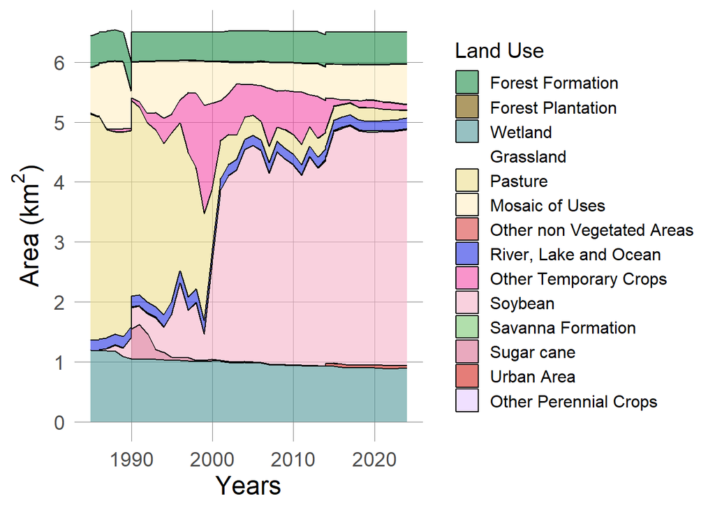

```r
results$time_series
```

# Mapas de uso e ocupaçãoLand use and land cover maps

Adicionalmente, o comando `land_vis` permite ao usuário visualizar o mapa de uso e ocupação da área para o ano de sua escolha. As cores e legendas seguem normas técnicas e foram importadas da plataforma MapBiomas.Additionally, the `land_vis` command allows the user to visualize the land use and land cover map for a chosen year. Colors and legends follow technical standards and were imported from the MapBiomas platform.

## Mapa da UFSCar Lagoa do Sino, ano de 1990UFSCar Lagoa do Sino map, year 1990

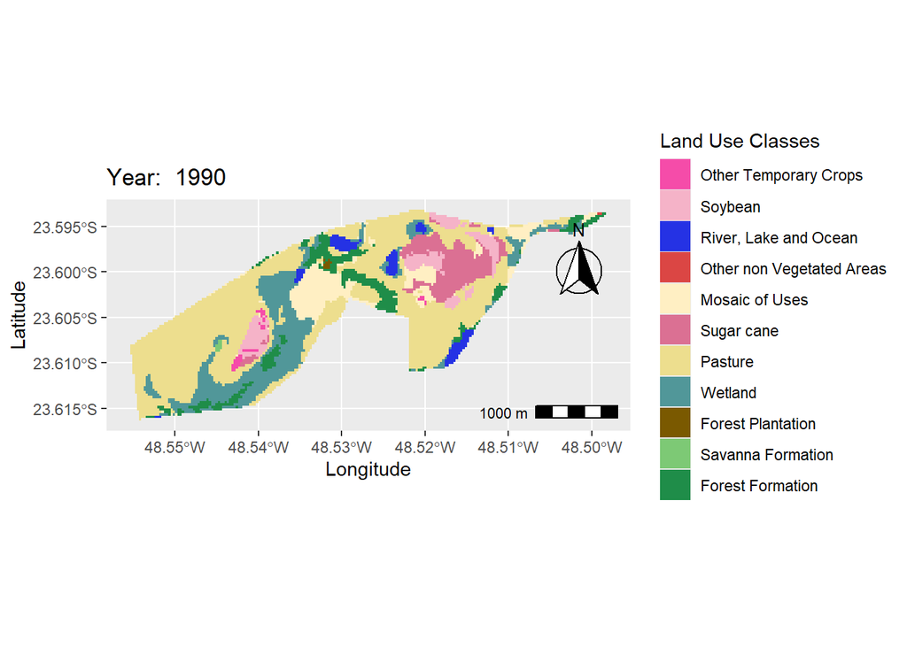

```r
land_vis(mapas, year = 1990)
```

## Mapa da UFSCar Lagoa do Sino, ano de 2024UFSCar Lagoa do Sino map, year 2024

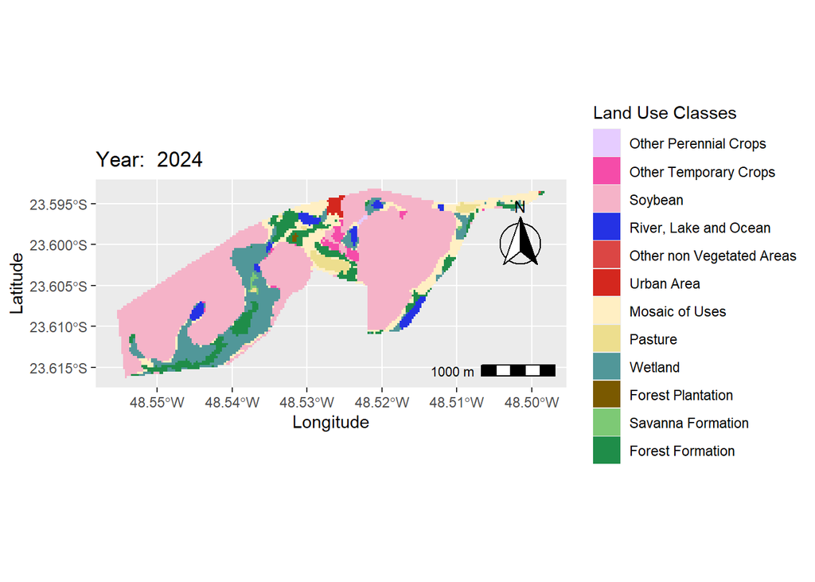

```r
land_vis(mapas, year = 2024)
```

# Integração de feições do OpenStreetMapOpenStreetMap feature integration

A função `integrate_feature` recebe um raster anual, uma lista de feições e uma lista de métricas. Cada feição é consultada e rasterizada apenas uma vez; o mesmo raster é então reutilizado pelos cálculos de distância e densidade. Isso reduz chamadas ao servidor Overpass e garante que as métricas usem exatamente a mesma representação espacial da feição.The `integrate_feature` function receives an annual raster, a feature list, and a metric list. Each feature is queried and rasterized only once; the same raster is then reused for distance and density calculations. This reduces Overpass requests and ensures that all metrics use exactly the same spatial representation of the feature.

No exemplo, as feições são vias principais (`highway = primary`) e rios (`waterway = river`). Para ambas são calculadas distância e densidade local, esta última com janela circular de 9 por 9 células. O argumento `plot` controla se os mapas em padrão `ggplot2` serão produzidos.In this example, the features are primary roads (`highway = primary`) and rivers (`waterway = river`). Distance and local density are calculated for both, with density using a 9 by 9 circular window. The `plot` argument controls whether standard `ggplot2` maps are produced.

```r
ano_distancia <- 2024
indice_ano <- ano_distancia - mapas$time_range[1] + 1
raster_anual <- mapas$raster[[indice_ano]]

integrated_features <- integrate_feature(
  reference_raster = raster_anual,
  features = list(
    roads = list(key = "highway", value = "primary"),
    rivers = list(key = "waterway", value = "river")
  ),
  metrics = list(
    distance = list(),
    density = list(window_size = 9, window_shape = "circle")
  ),
  osm_options = list(
    timeout = 60,
    use_cache = TRUE,
    cache_ttl_days = 7
  ),
  plot = TRUE
)
```

A consulta usa buffer padrão de 2 km, cache persistente por sete dias e alternância automática entre servidores Overpass globais. Se todos estiverem indisponíveis, um cache expirado ainda pode ser usado como contingência. Informar valores específicos para cada chave reduz o volume das consultas; para processamento intensivo de muitas áreas, recomenda-se uma extração regional PBF.The query uses a default 2 km buffer, a seven-day persistent cache, and automatic failover among global Overpass servers. If all are unavailable, an expired cache may still be used as a fallback. Providing specific values for each key reduces query volume; a regional PBF extract is recommended for intensive processing of many areas.

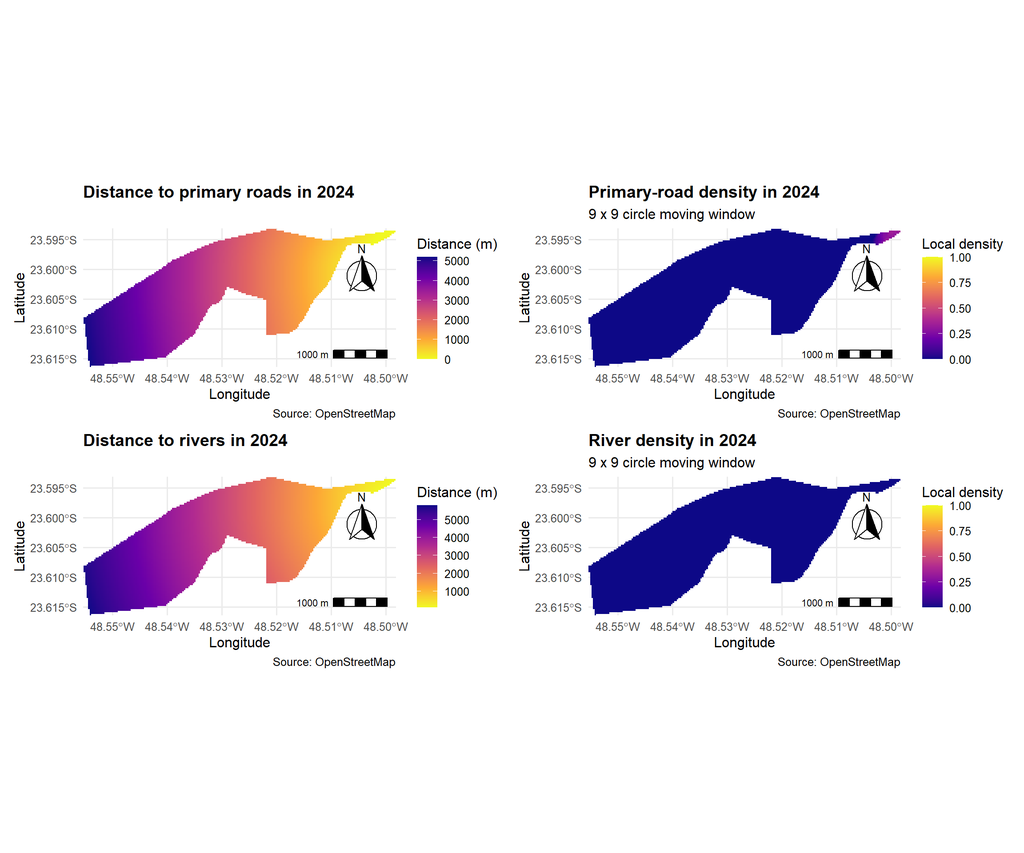

O painel foi gerado com a versão atual do pacote e preservado no tutorial para que a documentação possa ser recompilada mesmo quando os servidores públicos do Overpass estiverem indisponíveis. Os rasters calculados ficam em `results`, os rasters OSM carregados uma única vez ficam em `features`, o valor global da densidade fica em `results$roads$density$global` e os mapas exportáveis ficam em `plots`.The panel was generated with the current package version and preserved in the tutorial so the documentation can be rebuilt even when public Overpass servers are unavailable. Calculated rasters are stored in `results`, OSM rasters loaded once are stored in `features`, global density is stored in `results$roads$density$global`, and exportable maps are stored in `plots`.

# Distribuição de classesClass distribution

O comando `land_dist` apresenta a distribuição de classes, em termos de área total, para o ano de referência. As opções são gráfico de colunas (

[output not shown]

) e de pizza (`type = “pie”`).The `land_dist` command shows class distribution in terms of total area for the reference year. Options are column chart (`type = “barplot”`) and pie chart (

[output not shown]

).

## Gráfico de colunasColumn chart

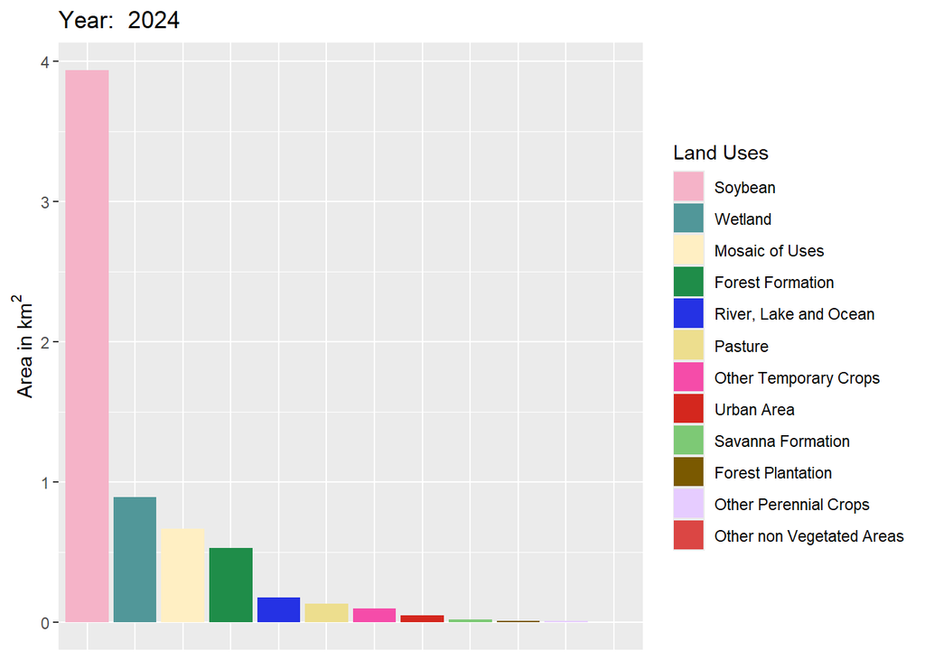

```r
land_dist(results, year = 2024, type = "barplot")
```

## Gráfico de setoresPie chart

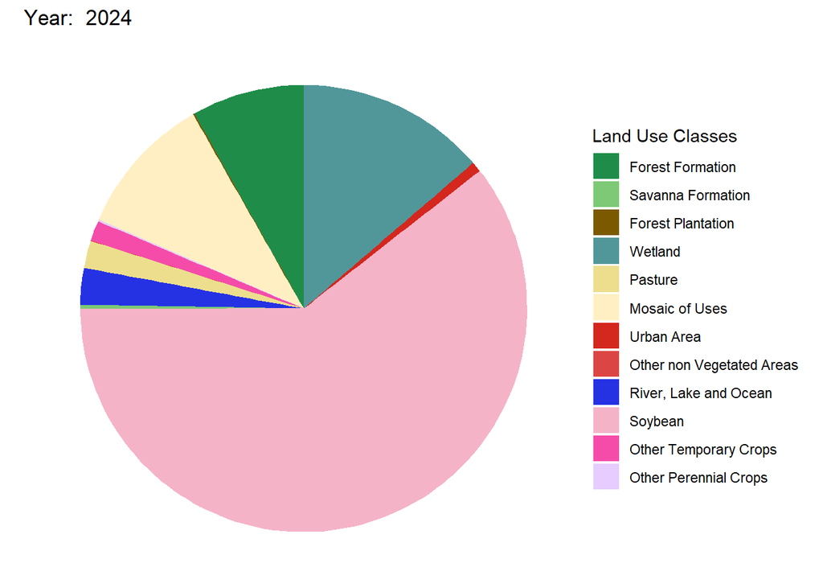

```r
land_dist(results, year = 2024, type = "pie")
```

# Métricas da paisagemLandscape metrics

O Bioma Stats também apresenta um módulo para a reclassificação e métricas da paisagem. O módulo é integrado com o programa `landscapemetrics` do R e possui uso intuitivo: na função `biomastats_metrics`, o usuário precisa passar o objeto no padrão biomastats, o horizonte de tempo, a zona de fuso horário, o hemisfério (`“south”` ou `“north”`) e as métricas de interesse (`“Frag. Avg. Area (ha)”`, `“Edge Length (m)”`, `“Edge Density (m/ha)”`, `“Total Reclassified Area (ha)”`,

[output not shown]

, `“Number of Fragments”`). Ao fazer

[output not shown]

, todas as métricas existentes no programa serão calculadas.Bioma Stats also provides a module for reclassification and landscape metrics. The module is integrated with the R `landscapemetrics` package and is intuitive to use: in `biomastats_metrics`, the user must pass the biomastats-standard object, the time range, the time zone, the hemisphere (`“south”` or `“north”`), and metrics of interest (`“Frag. Avg. Area (ha)”`,

[output not shown]

, `“Edge Density (m/ha)”`,

[output not shown]

, `“Aggregation Index (%)”`, `“Number of Fragments”`). With

[output not shown]

, all metrics available in the program will be calculated.

Por padrão (`classes = NULL`), o programa abre uma janela seletora para a escolha interativa das classes de uso e ocupação do solo. Para tornar a análise reprodutível, os códigos das classes também podem ser informados diretamente no argumento `classes`. No exemplo a seguir, selecionamos as classes florestais Formação Florestal (código 3) e Formação Savânica (código 4).By default (

[output not shown]

), the program opens a selector window for interactive choice of land use and land cover classes. To make the analysis reproducible, class codes can also be provided directly in the `classes` argument. In the example below, we select the forest classes Forest Formation (code 3) and Savanna Formation (code 4).

```r
plot_teste <- biomastats_metrics(mapas, start = 1985, end = 2024, zone = "22",
                                 hemisphere = "south", classes = c(3, 4),
                                 metrics = "keep.all")
```

As métricas são exportadas na forma de tabela, como retorno da função `biomastats_metrics`:Metrics are exported as a table returned by `biomastats_metrics`:

```r
head(plot_teste$metrics_table, 6)
```

```
##   Year Frag. Avg. Area (ha) Edge Length (m) Edge Density (m/ha)
## 1 1985             2.384525         17170.0            26.33257
## 2 1986             2.354625         16820.8            25.79702
## 3 1987             2.137850         17734.4            27.19815
## 4 1988             2.270125         17674.6            27.10644
## 5 1989             2.279875         16721.5            25.64473
## 6 1990             2.006290         17008.5            26.08489
##   Total Reclassified Area (ha) Aggregation Index (%) Number of Fragments
## 1                     52.45955              75.18367                  22
## 2                     51.80175              75.35153                  22
## 3                     51.30840              73.70618                  24
## 4                     52.21287              74.32322                  23
## 5                     50.15725              74.70085                  22
## 6                     50.15725              74.10256                  25
```

Elas também podem ser visualizadas em gráficos de séries temporais, como ilustram os exemplos a seguir:They can also be visualized in time series plots, as illustrated in the examples below:

## Área das classes selecionadasArea of selected classes

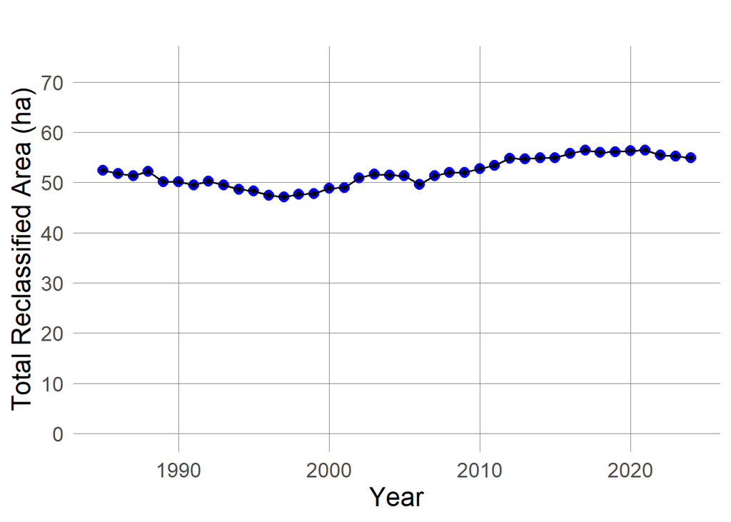

```r
plot_teste$area_plot
```

## Índice de agregação para as classes selecionadasAggregation index for selected classes

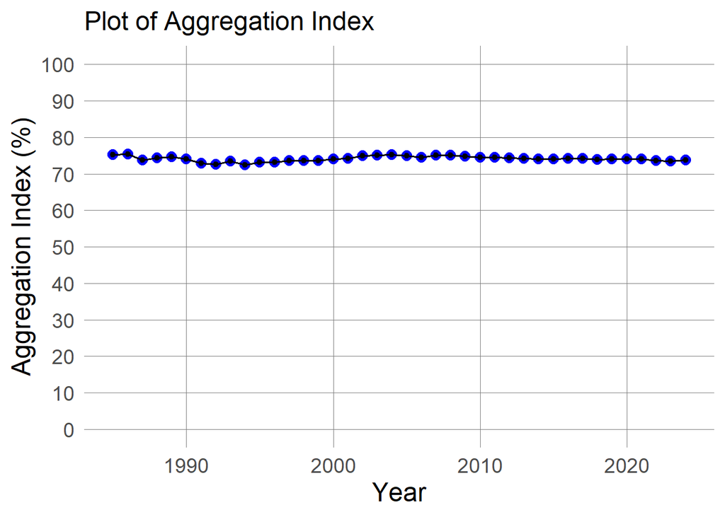

```r
plot_teste$ai_plot
```

## Gráficos customizáveisCustomizable plots

As saídas gráficas do *Bioma Stats* são objetos oriundos do pacote gráfico `ggplot2`. Dessa forma, os gráficos podem ser customizados usando a sintaxe introduzida por Hadley Wickham no `ggplot2`. Por exemplo, abaixo usamos a sintaxe do `ggplot2` para mudar a cor dos pontos e remover as grades de fundo.Graphical outputs from *Bioma Stats* are objects from the `ggplot2` package. Thus, plots can be customized using the syntax introduced by Hadley Wickham in `ggplot2`. For example, below we use `ggplot2` syntax to change point color and remove background grid lines.

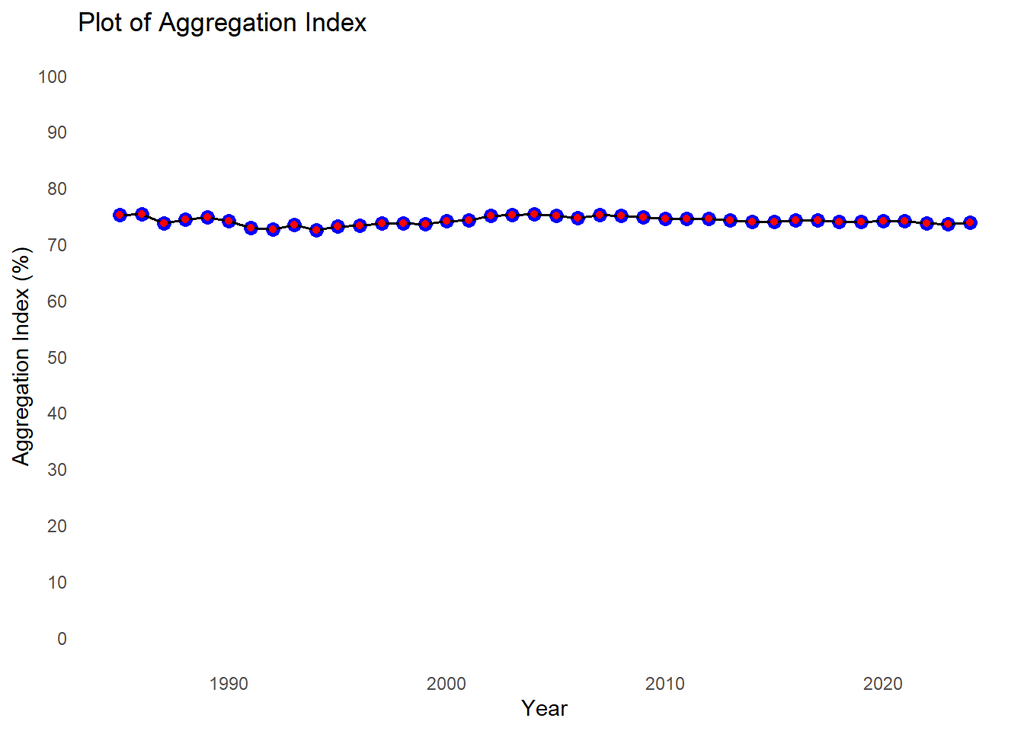

```r
# install.packages("ggplot2")
library(ggplot2)
plot_teste$ai_plot +
  geom_point(color = "red") +
  theme_minimal() +
  theme(panel.grid = element_blank())
```

# Dicionário de classes e mapas reclassificadosClass dictionary and reclassified maps

O *Bioma Stats* contém um dicionário de classes, indicando seus códigos, níveis hierárquicos, nomes em Português e Inglês, e cores padronizadas pela norma brasileira do IBGE.The *Bioma Stats* contains a class dictionary listing codes, hierarchical levels, names in Portuguese and English, and colors standardized by the Brazilian IBGE norm.

No exemplo a seguir, o dicionário é carregado a partir do comando `dict_build` e, com os códigos processados em `biomastats_metrics`, os nomes das classificações usadas são recuperados.In the example below, the dictionary is loaded with `dict_build` and, with the codes processed in `biomastats_metrics`, the names of the classifications used are retrieved.

```r
dicti <- biomastats:::dict_build()
dicti$class[dicti$code %in% plot_teste$classes]
```

```
## [1] "Savanna Formation" "Forest Formation"
```

# Mapas reclassificadosReclassified maps

O *Bioma Stats* também apresenta recurso para visualizar os mapas após a reclassificação. A função `reclass_map` processa objetos exportados pela função `biomastats_metrics` e, para usá-la, o usuário precisa apenas informar o objeto exportado (`obj = plot_teste`, por exemplo) e o ano de interesse.The *Bioma Stats* also provides a feature to visualize maps after reclassification. The `reclass_map` function processes objects exported by `biomastats_metrics`; to use it, the user only needs to provide the exported object (

[output not shown]

, for example) and the year of interest.

## Mapa da Lagoa do Sino reclassificado em 1985Lagoa do Sino reclassified map, year 1985

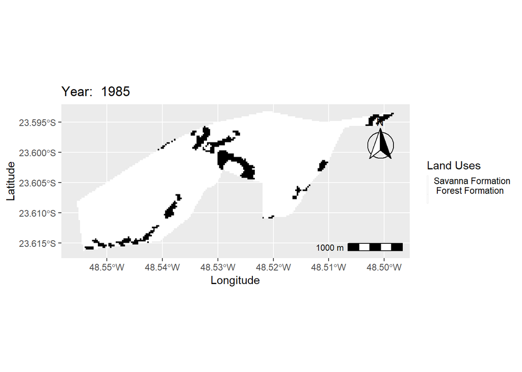

```r
reclass_map(obj = plot_teste, year = 1985)
```

## Mapa da Lagoa do Sino reclassificado em 2024Lagoa do Sino reclassified map, year 2024

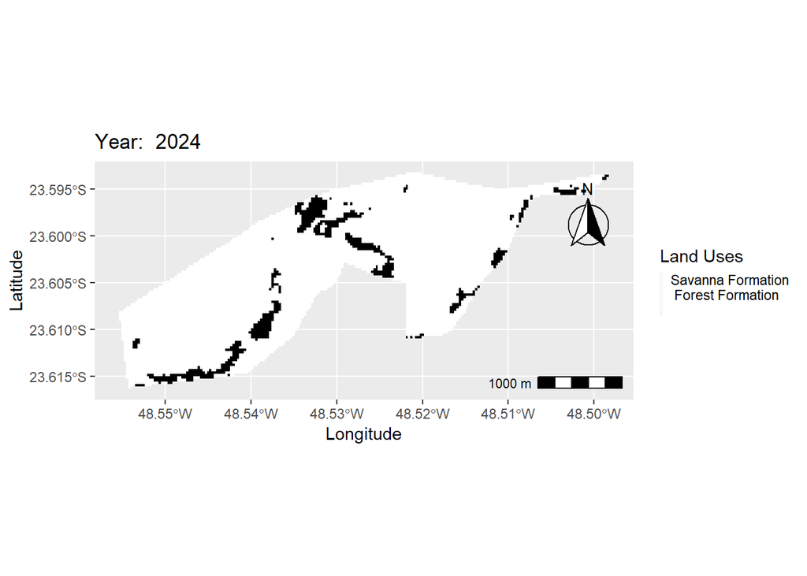

```r
reclass_map(obj = plot_teste, year = 2024)
```

# Contribua com o projetoContribute to the project

Se você deseja:If you would like to:

- Sugerir novas funcionalidades ao programaSuggest new features for the program
- Reportar errosReport errors
- Solicitar suporte técnicoRequest technical support
- Colaborar com o projetoCollaborate on the project

Entre em contato conosco por e-mailContact us by email

# AgradecimentosAcknowledgments

A equipe do CeMECA - UFSCar Lagoa do Sino agradece ao Projeto MapBiomas pela disponibilização das coleções de uso e cobertura da terra. Os dados utilizados neste estudo são provenientes do MapBiomas – Coleção 10 da Série Anual de Mapas de Cobertura e Uso do Solo do Brasil, acessados em https://mapbiomas.org.The CeMECA team at UFSCar Lagoa do Sino thanks the MapBiomas Project for providing land use and land cover collections. Data used in this study come from MapBiomas – Collection 10 of the Annual Series of Land Cover and Land Use Maps of Brazil, accessed at https://mapbiomas.org.

A equipe do CeMECA - UFSCar Lagoa do Sino agradece ao Conselho Nacional de Desenvolvimento Científico e Tecnológico (CNPq) pelo fomento 406540/2023 - 3.The CeMECA team at UFSCar Lagoa do Sino thanks the National Council for Scientific and Technological Development (CNPq) for funding 406540/2023 - 3.

Agradeço a equipe CeMECA pela colaboração no desenvolvimento e teste do Programa *Bioma Stats*:I thank the CeMECA team for collaboration in developing and testing the *Bioma Stats* program:

- **Kaik Octaviano Fontana** - Pré-processamento de dados**Kaik Octaviano Fontana** - Data preprocessing
- **Cristiano Augusto de Souza** - Funções de visualização**Cristiano Augusto de Souza** - Visualization functions
- **Paulo Guilherme Molin** (ctb) - Consultoria em GIS**Paulo Guilherme Molin** (ctb) - GIS consulting
- **Mateus Faria Santa** - Funções de visualização**Mateus Faria Santa** - Visualization functions
- **Ruth Silva Souza** - Funções de visualização**Ruth Silva Souza** - Visualization functions
- **Victor de Camargo Gomes** - Métricas de paisagem**Victor de Camargo Gomes** - Landscape metrics
- **Ana Beatriz Oliveira Prado** - Aquisição de dados e sistemas de comunicação**Ana Beatriz Oliveira Prado** - Data acquisition and communication systems
- **Gustavo Bilia Marques** - Aquisição de dados e sistemas de comunicação**Gustavo Bilia Marques** - Data acquisition and communication systems
- **João Vitor Valença Stefanini** - Sistemas de comunicação e visualização**João Vitor Valença Stefanini** - Communication systems and visualization

Agradeço aos prof. pesquisadores, membros do Projeto Universal CNPq 406540, que assessoram a equipe de desenvolvimento do *Bioma Stats* em diversas frentes:I thank the faculty researchers, members of CNPq Universal Project 406540, who advise the *Bioma Stats* development team in various areas:

- **Prof. Dr. Paulo Guilherme Molin** - Assessoria em Geotecnologias**Prof. Dr. Paulo Guilherme Molin** - Geotechnology advisory
- **Prof.ª Dr.ª Débora Cristina Rother** - Assessoria em Ecologia da Paisagem**Prof. Dr. Débora Cristina Rother** - Landscape ecology advisory
- **Prof. Dr. Heber Lombardi de Carvalho** - Assessoria em Gestão e Sistemas de Informação**Prof. Dr. Heber Lombardi de Carvalho** - Management and information systems advisory
- **Prof. Dr. Jorge Luis Rodrigues Pantoja Filho** - Assessoria em Meio Ambiente**Prof. Dr. Jorge Luis Rodrigues Pantoja Filho** - Environment advisory
- **Prof. Dr. Rafael de Oliveira Tiezzi** - Assessoria em Meio Ambiente**Prof. Dr. Rafael de Oliveira Tiezzi** - Environment advisory

# Termos de usoTerms of use

O código-fonte deste programa está protegido por direitos autorais e é regido pela Licença GNU Affero General Public License (GNU AGPL) versão 3.0 ou posterior. Qualquer redistribuição ou modificação do código-fonte deve ser realizada de acordo com os termos desta licença.The source code of this program is protected by copyright and is governed by the GNU Affero General Public License (GNU AGPL) version 3.0 or later. Any redistribution or modification of the source code must be carried out in accordance with the terms of this license.

É crucial destacar que a GNU AGPL estabelece a necessidade de que os autores do software sejam devidamente reconhecidos em qualquer redistribuição ou modificação efetuada no código-fonte original. Tal premissa se constitui como um requisito imprescindível para assegurar o respeito aos direitos autorais dos criadores do software, bem como para manter a transparência e a credibilidade do software, objetivos estes que são de grande relevância para toda a comunidade de usuários e desenvolvedores de software livre. Consequentemente, é fundamental observar tal exigência ao utilizar o programa.It is essential to note that the GNU AGPL requires that the software authors be properly acknowledged in any redistribution or modification of the original source code. This is an indispensable requirement to ensure respect for the copyright of the software creators and to maintain transparency and credibility of the software—goals of great relevance to the entire community of free software users and developers. Therefore, it is essential to observe this requirement when using the program.

Ao utilizar este programa, você concorda em cumprir os termos e condições estabelecidos pela Licença GNU Affero General Public License (GNU AGPL) versão 3.0 ou posterior. Para obter mais informações sobre a licença, consulte o arquivo “LICENSE” que acompanha este programa ou acesse o seguinte link: https://www.gnu.org/licenses/agpl-3.0.html.By using this program, you agree to comply with the terms and conditions established by the GNU Affero General Public License (GNU AGPL) version 3.0 or later. For more information about the license, see the “LICENSE” file that accompanies this program or visit: https://www.gnu.org/licenses/agpl-3.0.html.

# Declaração de uso de Inteligência ArtificialStatement on the use of Artificial Intelligence

Durante a preparação deste material e do pacote *Bioma Stats*, foram utilizadas ferramentas de Inteligência Artificial (IA) como apoio, sob supervisão e revisão da equipe. Especificamente, a IA foi empregada para:During the preparation of this material and of the *Bioma Stats* package, Artificial Intelligence (AI) tools were used as support, under the team’s supervision and review. Specifically, AI was used for:

- Refatoração e otimização de trechos de códigoRefactoring and optimization of code snippets
- Ajustes textuais e de redação (clareza, coesão e revisão)Textual and writing adjustments (clarity, cohesion, and proofreading)
- Transcrição e tradução de conteúdos do Português para o InglêsTranscription and translation of content from Portuguese into English

Todo o conteúdo gerado com auxílio de IA foi revisado e validado pelos autores, que assumem integral responsabilidade pelas informações apresentadas.All content produced with AI assistance was reviewed and validated by the authors, who take full responsibility for the information presented.